# A general model for the evolution of nuptial gift-giving

## S3: Alternative derivation of male fitness threshold

In the main text, we assumed that males made the decision to search or not search for a nuptial gift. The expected length of time for which searching males are expected to remain outside of the mating pool is $E[T_{\mathrm{m}}] = \alpha$ (see Methods). Alternatively, we can assume that males search for a period of $T_{\mathrm{m}}$ and spend this full duration of $T_{\mathrm{m}}$ in the time-out phase, even if they succeed in finding a nuptial gift. The probability that a male obtains a nuptial gift during this time is modelled in Eq. 1,

$$P(G) = 1 -
e^{-\frac{1}{\alpha}T_{\mathrm{m}}}.$$

In Eq. 1, $\alpha$ is the amount of time expected to pass before a male encounters a nuptial gift. We assume that a male will only enter the mating pool with no gift if they are unsuccessful in obtaining a gift, so the probability that a male obtains no gift after $T_{\mathrm{m}}$ is,

$$P(L) =
e^{-\frac{1}{\alpha}T_{\mathrm{m}}}.$$

We assume that the fitness increments to offspring associated with receiving a nuptial gift versus no nuptial gift are $1 + \gamma$ and 1, respectively. The rate at which males increase their fitness can then be defined as the expected fitness increment from their nuptial gift search divided by $T_{\mathrm{m}}$ plus the time spent in the mating pool waiting to encounter a mate,

$$W_{\mathrm{m}} = \lambda
\frac{P(G)\left(1 + \gamma\right) + P(L)}{T_{\mathrm{m}} + \left(
\frac{\beta + 1}{R} \right)}.$$

Our objective now is to determine the conditions under which a focal male increases its fitness by searching for a nuptial gift ($T_{\mathrm{m}}>0$) in a population of resident males that do not search ($T_{\mathrm{m}}=0$). Females are assumed to exhibit no choice in males with versus without nuptial gifts. Under such conditions, male fitness cannot be affected by female choice, so selection to increase $T_{\mathrm{m}}>0$ must be based solely on $\alpha$, $\beta$, $R$, and $\gamma$.

To determine under what conditions male inclusive fitness increases with nuptial gift search time, we can differentiate $W_{\mathrm{m}}$ with respect to $T_{\mathrm{m}}$,

$$\frac{\partial W_{\mathrm{m}}}{\partial
T_{\mathrm{m}}} = \lambda\frac{\gamma\left(\frac{\frac{T_{\mathrm{m}} +
\frac{\beta + 1}{R}}{\alpha} + 1}{e^{\frac{1}{\alpha}T_{\mathrm{m}}}} -
1\right) - 1}{\left(T_{\mathrm{m}} + \frac{\beta + 1}{R}
\right)^{2}}.$$

Because $T_{\mathrm{m}} = 0$, the above simplifies,

$$\frac{\partial W_{\mathrm{m}}}{\partial
T_{\mathrm{m}}} = \lambda \frac{\frac{R\gamma\left(\beta +
1\right)}{\alpha} - R^{2}}{\left(1 + \beta \right)^{2}}.$$

We can re-arrange the above,

$$\frac{\partial W_{\mathrm{m}}}{\partial
T_{\mathrm{m}}} = \lambda \frac{R\gamma}{\alpha\left(\beta+1\right)} -
\lambda\frac{R^{2}}{{\left(1 + \beta \right)^{2}}}.$$

Note that if $R = 0$ or $\lambda = 0$, then, trivially, no change in fitness occurs (since females and males cannot mate or do not produce offspring). Fitness is increased by searching for nuptial gifts when $\gamma$ is high, scaled by the expect search time needed to find a nuptial gift. A second term on the right-hand side is subtracted, which reflects a loss in fitness proportional to the encounter rate of potential mates in the mating pool. The conditions under which male inclusive fitness increases by searching for a nuptial gift are found by setting $\partial W_{\mathrm{m}}/\partial T_{\mathrm{m}} = 0$ and solving for $\gamma$ to get Eq. 2 in the main text.

## S4: Operational sex ratio

We assume that the ratio of males to females is the same upon individual maturation. Consequently, the operational sex ratio $\beta$ will be a function of $R$, $T_{\mathrm{f}}$, and $T_{\mathrm{m}}$ because these parameters determine the density of females and males in the mating pool versus outside of the mating pool. We start with the definition of $\beta$ as being the probability of finding an individual in time-in (Kokko & Monaghan, 2001),

$$\beta =
\frac{\int_{t=0}^{\infty}P_{IM}(t)dt}{\int_{t=0}^{\infty}P_{IF}(t)dt}$$

We can substitute the equations for $P_{IM}(t)$ and $P_{IF}(t)$, which define the probabilities of males and females being within the mating pool at time $t$, respectively.

We can therefore calculate $\beta$ as below,

$$\beta = \frac{\left(
\frac{\left(\frac{\beta + 1}{R}\right)}{T_{\mathrm{m}} +
\left(\frac{\beta + 1}{R}\right)} \right)}{\left( \frac{\left(R
\frac{\beta}{\beta + 1}\right)}{T_{\mathrm{f}} + \left(R
\frac{\beta}{\beta + 1}\right)} \right)}.$$

This can be simplified,

$$\beta = \frac{\left(\beta\left(R +
T_{f}\right) + T_{f}\right)\left(\beta + 1\right)}{\beta
\left(R^{2}T_{m} + R\right) + \beta^{2}R}.$$

There is no closed form solution for $\beta$, but a recursive algorithm can be used to calculate $\beta$ to an arbitrary degree of precision.

```r
recursive_b <- function(B, D, Tf, Tm, crit = 0.0001, maxit = 9999){
  conv <- 1;
  iter <- 0;
  while(conv > crit & iter < maxit){
    Fe   <- D * (B / (1 + B));
    Me   <- (1 + B) / D;
    Bn   <- (Me / (Tm + Me)) / (Fe / (Tf + Fe));
    iter <- iter + 1;
    conv <- abs(Bn - B);
    B    <- Bn;
  }
  return(list(B = B, conv = conv, iter = iter));
}
```

We used the above function to calculate values of $\beta$ for the analytical model.

## S5: Estimation of key model parameters using experimental data

Estimates showing the mean number of offspring produced by female *Pisaura mirabilis* that ate nuptial gifts and females who did not. Means were calculated with raw data from Tuni *et al.* (2013) and results are shown $\pm$ SE (Table 1). Under these assumptions, the relative gain in fitness from receiving nuptial gifts for a female is,

$$\hat{\delta_\mathrm{f}} =
\frac{25.74}{6.00} = 4.29$$

Since the baseline fitness is 1, the increase in fitness resulting from a nuptial gift then becomes,

$$\hat{\gamma} = \hat{\delta_{\mathrm{f}}}
- 1 = 3.29.$$

The value 3.29 was used to parameterise $\gamma$ for a set of simulations (Figure 4 in the main text).

|  | Received nuptial gift | Received no nuptial gift |
| --- | --- | --- |
| Expected number of hatched eggs | $25.74 \pm 0.96$ | $6.00 \pm 2.1$ |

Table 1: Estimates showing mean number of offspring produced by female *P. mirabilis* that ate nuptial gifts and females who did not. Means were calculated with raw data from Tuni *et al.* (2013) and results are shown $\pm$ SE.

## S6: Separate evolution of male search and female choice

We used the individual-based simulation model (see Supporting Information S1) to unpack the effect of coevolution on the evolution of male search and female choice. Here we replicated the simulations shown in the main text under the condition where only one trait at a time was allowed to evolve and studied how this affected the trait evolution.

First, we submitted a set of simulations wherein male search did not evolve, but was fixed at different values (see Fig. S6.1). Next, we ran the same set of simulations wherein male search evolved, but female choice was not possible. The results thus show how each trait evolves in the absence of any coevolution (Fig. S6.1).

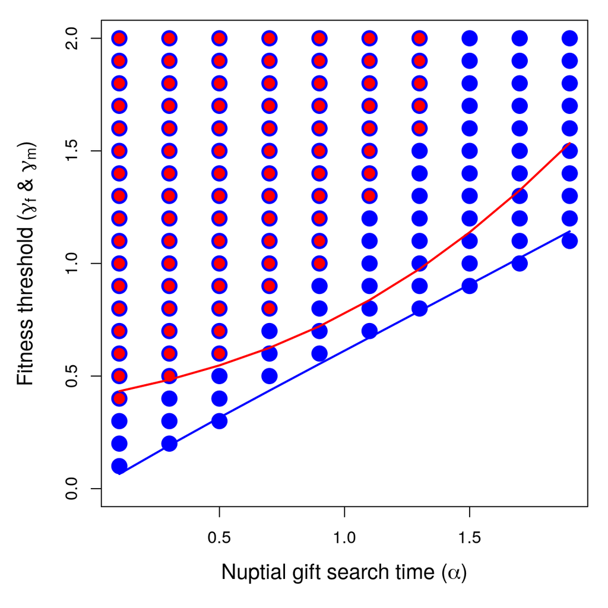